# Esercitazione 10

## Istruzioni

Valgono le stesse istruzioni delle esercitazioni precedenti.

Scrivi il programma Python nella cella sotto il testo dell'esercizio (o creane una nuova). Stampa sempre a video il risultato finale per verificare la correttezza dell'esercizio. Talvolta richiamiamo alcuni concetti importanti in una cella di codice sotto il testo dell'esercizio, prova a eseguirla ed eventualmente modificarla per assicurarti di aver capito il necessario.

**Nota.** Alcuni esercizi potrebbero richiedere una semplice risposta a delle domande. In questo caso potete scrivere la soluzione in una cella di tipo "Markdown".

## Consegna

Valgono le regole delle esercitazioni precedenti.

E' obbligatorio **consegnare la soluzione di tutti gli esercizi** (tranne quelli marcati come opzionali) **entro l'inizio della lezione successiva** (in questo caso entro Lunedi' prossimo), nell'apposito assignment su iCorsi. Per consegnare:

- eseguire l'intero notebook partendo da zero (`Kernel -> Restart & Run All`), e controllare che le soluzioni siano quelle attese;
- esportare il notebook in formato html (`File -> Download as...`) e consegnare il file risultante.

Nel caso non abbiate potuto completare uno o piu' esercizi, descrivete il problema incontrato e **consegnate comunque il file con il resto delle soluzioni**.

## Esercizio 1

Si implementi l'algoritmo di clustering $k$-means. Nello specifico, si scriva una funzione `Kmeans` che riceve come parametri di ingresso:

- `n_cluster`: numero di clusters ($k$)
- `x`: osservazioni: vettore a 2 dimensioni con m righe (dove m è il numero di istanze) e n colonne (dove n è il numero di attributi)
- `xC`: condizioni iniziali (ossia, valore iniziale dei centroidi del clusters). Sarà un vettore a 2 dimensioni con `n_clusters` righe e `n` colonne
- `max_iter`: numero massimo di iterazioni dell'algoritmo k-means

La funzione restituisce:

- `y`: vettore a 1 dimensione di lunghezza m. Ogni elemento del vettore rappresenta il cluster a cui è associata l'osservazione. Nota che se si considerano `n_cluster=3` clusters, allora ogni elemento di y puo' assumere valori 0, 1 o 2.
- `xC`: posizione finale dei centroidi del clusters. Sarà un array a 2 dimensioni con `n_cluster` righe e `n` colonne.

Testate il funzionamento della funzione costruita su un dataset di dati sintetici con 2 attributi, generati (e plottati) eseguendo la cella sotto. Ricordatevi di:

- Normalizzare gli attributi prima di eseguire la funzione Kmeans
- In base al plot delle osservazioni, scegliete un numero di clusters ragionevole
- Poichè abbiamo solo 2 attributi, riplottate le osservazioni colorando il punto in base al cluster a cui è stato assegnato (es. plottate in blu tutti i punti assegnati al primo cluster, in rosso tutti i punti assegnati al secondo cluster, in verde tutti i punti assegnati al terzo cluster).
- Plottate anche la posizione del centroide di ogni cluster. Ad esempio, potrebbe venirvi un risultato tipo questo:

[figure not shown]

```python
# Data generation

import numpy as np
import plotly.offline as py
import plotly.graph_objs as go
py.init_notebook_mode(connected = True)


m = 100 # Number of observations

# generate first feature
x1_1 = np.linspace(0,1,33)
x1_2 = np.linspace(1,2,33)
x1_3 = np.linspace(2,3,34)

x1 = np.concatenate((x1_1,x1_2,x1_3))
x1 = np.reshape(x1,(-1,1))


# generate second feature
x2_1 = np.random.rand(33)*10
x2_2 = np.random.rand(33)*10 + 10
x2_3 = np.random.rand(34)*10 + 20

x2 = np.concatenate((x2_1,x2_2,x2_3))
x2 = np.reshape(x2,(-1,1))

# Put first and second features in a single 2-D array
x = np.concatenate((x1,x2), axis = 1)

# Plot
data = go.Scatter(x = x1[:,0], y = x2[:,0], mode = 'markers')


layout = go.Layout(xaxis = dict(title = 'Feature 1'), yaxis = dict(title = 'Feature 2'), title = 'Scatter plot delle osservazioni generate')
fig = go.Figure([data], layout)
py.iplot(fig)
```

[interactive chart not shown]

```python
# Solution (to be completed)
import math

def findDistance(p1 ,p2, n_attr):
    dist = 0
    for i in range(n_attr):
        dist += math.fabs(p1[i]-p2[i])
    return dist

def Kmeans(n_clusters, x, xC, max_iter):
    dist = np.zeros( (np.shape(x)[0],n_clusters))
    y = np.zeros(np.shape(x)[0])# Inizializzo matrice delle distanze (per ogni osservazione, calcolo la distanza dal centroide di ogni cluster)
    yCount = np.zeros(xC.shape[0])
    count=0
    while(count < max_iter):
        yCount = np.zeros(xC.shape[0])

        for elIndex in range(np.shape(x)[0]):
            for clusterIndex in range(n_clusters):
                dist[elIndex][clusterIndex] = findDistance(xC[clusterIndex],x[elIndex], x.shape[1])
        #distanze trovate

        testExit = 0
        for elIndex in range(np.shape(x)[0]):
            temp = y[elIndex]
            y[elIndex] = np.where(dist[elIndex] == dist[elIndex].min())[0][0]
            if(temp != y[elIndex]):
                testExit = 1
        if(testExit == 0):
            return y, xC
        #trovato il cluster di appartenenza
        xC = np.zeros((n_clusters,np.shape(x)[1]))
        for elIndex in range(np.shape(x)[0]):
            indiceCluster = int(y[elIndex])
            yCount[indiceCluster] += 1
            for i in range(np.shape(x)[1]):
                xC[indiceCluster][i] += x[elIndex][i]

        for i in range(n_clusters):
            for j in range(np.shape(x)[1]):
                xC[i][j] = xC[i][j]/yCount[i]
        #xC ricalcolato
        #fine
        count = count + 1

    return y, xC



n_clusters = 3
max_iter = 100


xMean = np.mean(x, axis = 0)
xStd  = np.std(x, axis = 0)
xScaled = (x-xMean)/xStd

np.random.shuffle(xScaled) # Scegli in maniera casuale i centroidi iniziali (mischia le osservazioni e scegli le prime "n_clusters" come centroidi iniziali)
xC = xScaled[0:n_clusters,:] # Centroidi iniziali


(y, xC) = Kmeans(n_clusters, xScaled, xC, max_iter)



x = xScaled*xStd + xMean   # Denormalize data before plotting
xC = xC*xStd + xMean

data = []

colorNames = ['blue', 'red', 'green', 'darkgray', 'yellow', 'yellowgreen', 'violet', 'pink']

for i in range(n_clusters):
    col =i%len(colorNames)
    data.append(go.Scatter(x = x[y==i,0], y = x[y==i,1], mode = 'markers', name = f'cluster {i+1}', marker = dict(color = colorNames[col])))
    data.append(go.Scatter(x = [xC[i][0]], y = [xC[i][1]], mode = 'markers', name = f'cluster {i+1} centre', marker = dict(color = colorNames[col], size=15)))

layout = go.Layout(xaxis = dict(title = ' Feature 1'), yaxis = dict(title = ' Feature 2'), title = 'Osservazioni clusterizzate')
fig = go.Figure(data, layout)
py.iplot(fig)
```

[interactive chart not shown]

## Esercizio 2

Si consideri il set di dati sintetici generati nell'esercizio precedente. Ripete l'operazione di clustering usando la funzione KMeans di sklearn. Esempi di applicazione della funzione KMeans potete trovarli [qui](https://scikit-learn.org/stable/modules/generated/sklearn.cluster.KMeans.html)

E' possibile che la funzione da voi implementata e la funzione del modulo sklearn restituiscano 2 risultati diversi? Perchè?

```python
# Solution (to be completed)


from sklearn.cluster import KMeans

cls = KMeans(n_clusters=n_clusters, max_iter=100)
cls.fit(xScaled)

y = cls.labels_  # labels ricavate
xC = cls.cluster_centers_ # Final clusters' centroids
xC = xC*xStd + xMean

dataSK = []

for i in range(n_clusters):
    col =i%len(colorNames)
    dataSK.append(go.Scatter(x = x[y==i,0], y = x[y==i,1], mode = 'markers', name = f'cluster {i+1}', marker = dict(color = colorNames[col])))
    dataSK.append(go.Scatter(x = [xC[i][0]], y = [xC[i][1]], mode = 'markers', name = f'cluster {i+1} centre', marker = dict(color = colorNames[col], size=15)))

layout = go.Layout(xaxis = dict(title = ' Feature 1'), yaxis = dict(title = ' Feature 2'), title = 'Osservazioni clusterizzate')
fig = go.Figure(dataSK, layout)
py.iplot(fig)
```

[interactive chart not shown]

Sì, è possibile che la funzione KMeans di sklearn e l'algoritmo da me sviluppato ritornino due risultati diversi e questo fatto è causato dalla scelta di valori differenti di pertenza per gli algoritmi di Kmean, questo effetto risulta più visibile nel caso in cui i gruppi non siano così ben delineati come in questo caso.

# Esercizio 3 (opzionale, ma divertente)

In questo esercizio useremo l'algoritmo K-Means per la quantizzazione dei colori in un immagine, con l'obiettivo finale di comprimere l'immagine.

Per prima cosa, carichiamo un'immagine eseguendo la cella sotto. L'immagine che caricheremo rappresenta un panorama ed è disponibile online (con licenza di riutilizzo e modifica) al seguente [link](https://pxhere.com/it/photo/984644). Se volete, potete usare un'altra immagine a vostro piacere.

```python
from skimage import io
import os
from sklearn.cluster import KMeans

image = io.imread('./panorama.jpg')
io.imshow(image)
io.show()

rows = image.shape[0]
cols = image.shape[1]

print(f"Risoluzione: {rows}x{cols} pixels")
```

[output not shown]

```
Risoluzione: 800x1200 pixels
```

Eseguendo la cella sotto, noterete che l'immagine appena caricata è codificata come un array a 3 dimensioni. La prima e seconda dimensione hanno lunghezza 800 e 1200 (questa è la risoluzione dell'immagine in pixels), mentre la terza dimensione ha lunghezza 3.

Ad un dato pixel sono infatti associati 3 numeri interi da 0 a 255, che rappresentano il colore del pixel secondo la codifica [*rgb*](https://it.wikipedia.org/wiki/RGB) (il primo valore rappresenta l'intensità del rosso, il secondo del verde, il terzo del blu).

Notate che, secondo questa codifica, ad ogni pixel è associata un informazione su 3 byte (1 byte per il rosso, uno per il verde, uno per il blu). In tutto, posso codificare 256x256x256 = 16777216 colori diversi!

```python
print(f"Image type: {type(image)}; shape: {image.shape}")
print(f"Primo pixel: rgb={image[0,0,0], image[0,0,1], image[0,0,2]}")
```

```
Image type: <class 'numpy.ndarray'>; shape: (800, 1200, 3)
Primo pixel: rgb=(127, 211, 255)
```

## 3.1

Vogliamo comprimere l'immagine, riducendo il numero di possibili colori ad un numero molto ristretto (nello specifico, un numero pari a 4).

Per fare questo, trattate ogni pixel come un'osservazione, a cui sono associati 3 attributi (i 3 valori numerici della codifica rgb). In tutto avete quindi 800x1200=960000 istanze (o osservazioni). Eseguiamo la cella sotto per fare un reshape dell'immagine, in modo da avere un array con 960000 righe e 3 colonne.

```python
x = image.reshape(image.shape[0]*image.shape[1],3)
x1=x[:60000,:]
print("ciao",x1)
print(x1.shape)
data=[]
data.append(go.Scatter3d(x = x1[:,0],y = x1[:,1],z=x1[:,2],mode = 'markers',marker=dict(
        size=3,)))
fig = go.Figure(data=data)
py.iplot(fig)
```

```
ciao [[127 211 255]
 [127 211 255]
 [126 210 254]
 ...
 [  8   9   1]
 [ 10  11   3]
 [ 10  11   3]]
(60000, 3)
```

[interactive chart not shown]

Provate a capire come usare l'algoritmo k-means per scegliere i "4" colori in maniera automatica (e "ottimale" per l'immagine considerata!)

Indicazioni e consigli:

### 3.1.1

Clusterizzare le osservazioni (ossia, i pixels dell'immagine originale) in *n_clusters = 4* clusters, usando come attributi i 3 valori della codifica rgb. In questo modo, punti con colori simili saranno raggruppati nello stesso cluster.

```python
# Solution to Part 3.1 (to be completed)

# Se avete fatto l'esercizio 2 sapete come usare la funzione KMeans di sklearn. Altrimenti usate la funzione che avete costruito al punto 1

cls = KMeans(4, max_iter=50) # Keep the number of maximum iterations small (ex. 50), otherwise the algorithm may take a lot of time before convergence
cls.fit(x)
```

```
KMeans(algorithm='auto', copy_x=True, init='k-means++', max_iter=50,
    n_clusters=4, n_init=10, n_jobs=1, precompute_distances='auto',
    random_state=None, tol=0.0001, verbose=0)
```

### 3.1.2

Ogni cluster rappresenterà quindi un gruppo di pixels con colori "simili". Il centroide del cluster sarà una "media" dei colori tra i pixels appartenenti allo stesso cluster. I centroidi dei "4" clusters saro quindi i colori (in formato rgb) che utilizzerete per la compressione dell'immagine.

Visualizzate i centroidi dei clusters e il vettore y che rappresenta a quale cluster è assegnato ogni pixel.

Noterete che i centroidi del cluster sono in reltà numeri in formato float. Troncateli convertendoli a numeri interi a 8 bit senza segno (in questo modo avrete numeri interi compresi tra 0 e 255). Si veda la cella sotto per capire come fare la conversione.

```python
# Solution (to be completed)

labels = cls.labels_
centroids = cls.cluster_centers_
print(f"Labels assegnati ad ogni punto: {labels}")
print(f"Clusters' centroids: {centroids}")

centroids = np.asarray(centroids,dtype=np.uint8)
print(f"Clusters' centroids arrotondati: {centroids}")
```

```
Labels assegnati ad ogni punto: [1 1 1 ... 3 3 3]
Clusters' centroids: [[ 87.73886867 109.91409035  49.85317976]
 [157.83398288 218.43204439 241.4602234 ]
 [159.54164393 169.0970836   69.96851733]
 [ 21.94645944  36.67391735  15.36635039]]
Clusters' centroids arrotondati: [[ 87 109  49]
 [157 218 241]
 [159 169  69]
 [ 21  36  15]]
```

### 3.1.3

Ad ogni pixel è adesso assegnato il cluster di appartenenza, e quindi uno dei 4 colori "ottimali" scelti in maniera automatica.

Ristampate l'immagine con i 4 colori quantizzati, riorganizzando il vettore di pixels in un array a 3 dimensioni, con le lunghezza con 800x1200x3 (ossia: risoluzione 800x1200 pixel, ad ogni pixel sono associati 3 numeri nella codifica rgb)

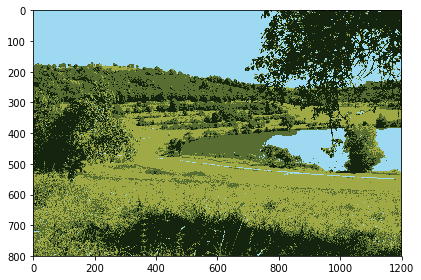

```python
# Solution (to be completed)

# Facciamo un reshape delle labels in modo da organizzarle in una matrice 800x1200
labels = labels.reshape(rows,cols)

# Costruiamo l'immagine con i nuovi colori

imageCompress = np.zeros((rows,cols,3),dtype=np.uint8 ) # Inizializziamo l'immagine (o meglio, la matrice che descrive l'immagine)
for i in range(rows):
    for j in range(cols):
            imageCompress[i,j,:] = centroids[labels[i][j]] # Qui metto il colore (nella codifica rgb) del pixel (i,j).


# Visualizziamo l'immagine
io.imshow(imageCompress)
io.show()
```

### 3.1.4

Visualizzando l'immagine sopra, riuscite a capire quali colori sono stati scelti?

**Solution**

3 diverse tonalità di verde e celeste

## 3.2

Ripetete l'esercizio raffinando la quantizzazione dei colori (ossia, aumentando il numero di clusters). Osservate come cambia l'immagine

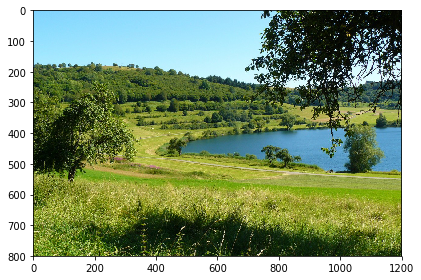

```
Risoluzione: 800x1200 pixels
Labels assegnati ad ogni punto: [1 1 1 ... 2 2 2]
Clusters' centroids: [[127.98450226 145.46540697  39.43559401]
 [156.09473426 225.63707846 252.89378227]
 [ 13.93901064  26.47330108  10.59613911]
 [194.64597609 195.79789008 110.04577514]
 [ 76.00644811 110.05401767 104.65423497]
 [ 45.13850403  65.11144551  29.20467767]
 [161.88856516 169.50624162  69.52218856]
 [196.72686155 241.76856915 251.28778245]
 [ 87.19747574 105.71321757  34.54098446]
 [ 97.23352127 156.20406222 189.84391912]]
Clusters' centroids arrotondati: [[127 145  39]
 [156 225 252]
 [ 13  26  10]
 [194 195 110]
 [ 76 110 104]
 [ 45  65  29]
 [161 169  69]
 [196 241 251]
 [ 87 105  34]
 [ 97 156 189]]
```

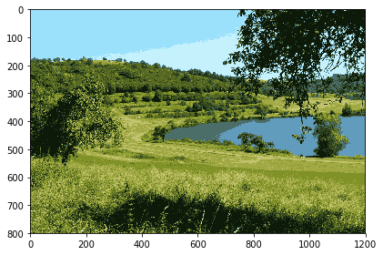

```python
from skimage import io
import os
from sklearn.cluster import KMeans

image = io.imread('./panorama.jpg')
io.imshow(image)
io.show()

rows = image.shape[0]
cols = image.shape[1]

print(f"Risoluzione: {rows}x{cols} pixels")


x = image.reshape(image.shape[0]*image.shape[1],3)

cls = KMeans(10, max_iter=50) # Keep the number of maximum iterations small (ex. 50), otherwise the algorithm may take a lot of time before convergence
cls.fit(x)

labels = cls.labels_
centroids = cls.cluster_centers_
print(f"Labels assegnati ad ogni punto: {labels}")
print(f"Clusters' centroids: {centroids}")

centroids = np.asarray(centroids,dtype=np.uint8)
print(f"Clusters' centroids arrotondati: {centroids}")


# Facciamo un reshape delle labels in modo da organizzarle in una matrice 800x1200
labels = labels.reshape(rows,cols)

# Costruiamo l'immagine con i nuovi colori

imageCompress = np.zeros((rows,cols,3),dtype=np.uint8 ) # Inizializziamo l'immagine (o meglio, la matrice che descrive l'immagine)
for i in range(rows):
    for j in range(cols):
            imageCompress[i,j,:] = centroids[labels[i][j]] # Qui metto il colore (nella codifica rgb) del pixel (i,j).


# Visualizziamo l'immagine
io.imshow(imageCompress)
io.show()
```

## 3.3

Provate il vostro sistema su immagini diverse

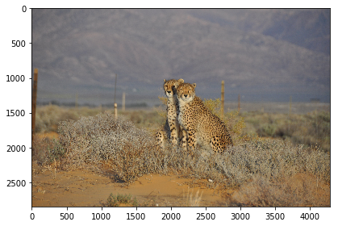

```
Risoluzione: 2848x4288 pixels
Labels assegnati ad ogni punto: [2 2 2 ... 0 0 0]
Clusters' centroids: [[ 97.15810618  79.98924167  61.91044599]
 [167.53413005 141.87955456 101.48181122]
 [119.91813748 118.29947375 123.13582313]
 [140.25838074 113.53049484  77.03374493]]
Clusters' centroids arrotondati: [[ 97  79  61]
 [167 141 101]
 [119 118 123]
 [140 113  77]]
```

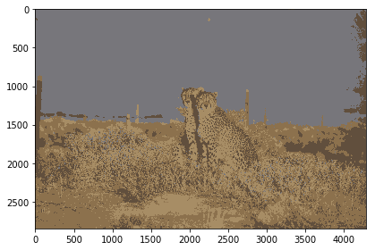

```python
from skimage import io
import os
from sklearn.cluster import KMeans

image = io.imread('./foto_g.jpg')
io.imshow(image)
io.show()

rows = image.shape[0]
cols = image.shape[1]

print(f"Risoluzione: {rows}x{cols} pixels")


x = image.reshape(image.shape[0]*image.shape[1],3)

cls = KMeans(4, max_iter=50) # Keep the number of maximum iterations small (ex. 50), otherwise the algorithm may take a lot of time before convergence
cls.fit(x)

labels = cls.labels_
centroids = cls.cluster_centers_
print(f"Labels assegnati ad ogni punto: {labels}")
print(f"Clusters' centroids: {centroids}")

centroids = np.asarray(centroids,dtype=np.uint8)
print(f"Clusters' centroids arrotondati: {centroids}")


# Facciamo un reshape delle labels in modo da organizzarle in una matrice 800x1200
labels = labels.reshape(rows,cols)

# Costruiamo l'immagine con i nuovi colori

imageCompress = np.zeros((rows,cols,3),dtype=np.uint8 ) # Inizializziamo l'immagine (o meglio, la matrice che descrive l'immagine)
for i in range(rows):
    for j in range(cols):
            imageCompress[i,j,:] = centroids[labels[i][j]] # Qui metto il colore (nella codifica rgb) del pixel (i,j).


# Visualizziamo l'immagine
io.imshow(imageCompress)
io.show()
```